# R DataMining & Data Viz’

Le but de ce projet est d’appliquer nos connaissances en dataming ET en data viz’ pour analyser et construire une problématique autour d’un dataset de [Kaggle](https://www.kaggle.com/austinreese/craigslist-carstrucks-data).

C’est pourquoi dans un premier temps, nous allons vous présenter notre rapide EDA et le traitement des variables (valeurs aberrantes et manquantes).

### Liste des packages à installer pour faire fonction le code

```r
list.of.packages= c("data.table", "naniar", "ggplot2", "dplyr", "tidyr", "rworldmap"
                    , "corrplot", "rstudioapi", "VIM")
install.packages(list.of.packages)
library(rstudioapi)
# Set active directory to the document currently opened in RStudio
current_path = rstudioapi::getActiveDocumentContext()$path
```

```
## Error: RStudio not running
```

```r
setwd(dirname(current_path ))
```

```
## Error in dirname(current_path): object 'current_path' not found
```

```r
print( getwd() )
```

```
## [1] "C:/Users/paull/Desktop/MoSEF/Data Mining in R/craigslistVehicles"
```

```r
library(data.table)
library(naniar) #pour plot les valeurs manquantes
library(ggplot2)
#library(tidyverse)#PROBLEME AVEC CETTE LIBRAIRIE!!!!!!!!!
#install.packages("tidyverse")
library(dplyr) # pour le recode
library(tidyr) #drop na
#install.packages("zoo")
library(rworldmap)
#install.packages("rworldmap")
library(corrplot)
library(VIM)
```

*Attention* de bien vérifier le chemin (logiquement la cellule précédente a dû régler le chemin)

## Data Exploration et traitement de nos features

```r
dim(data)
```

```
## [1] 525839     22
```

```r
colnames(data)
```

```
##  [1] "url"          "city"         "city_url"     "price"        "year"
##  [6] "manufacturer" "make"         "condition"    "cylinders"    "fuel"
## [11] "odometer"     "title_status" "transmission" "VIN"          "drive"
## [16] "size"         "type"         "paint_color"  "image_url"    "desc"
## [21] "lat"          "long"
```

```r
head(data)
```

| url | city | city_url | price | year | manufacturer | make | condition | cylinders | fuel | odometer | title_status | transmission | VIN | drive | size | type | paint_color | image_url | desc | lat | long |
| --- | --- | --- | --- | --- | --- | --- | --- | --- | --- | --- | --- | --- | --- | --- | --- | --- | --- | --- | --- | --- | --- |
| https://grandrapids.craigslist.org/cto/d/hastings-2006-cadillac-cts/7022515875.html | grand rapids, MI | https://grandrapids.craigslist.org | 1500 | 2006 | cadillac | cts | good | 6 cylinders | gas | 236000 | clean | automatic | NA | rwd | mid-size | coupe | blue | https://images.craigslist.org/00K0K_a9CZoZg2U8q_600x450.jpg | 2006 CtS Leather, Runs and drives Good.236k mil | 42.64300 | -85.29370 |
| https://grandrapids.craigslist.org/cto/d/grand-rapids-2009-lincoln-mkx-loaded/7022515214.html | grand rapids, MI | https://grandrapids.craigslist.org | 8900 | 2009 | lincoln | mkx | NA | NA | gas | 119000 | clean | automatic | NA | NA | NA | NA | NA | https://images.craigslist.org/00a0a_9B4kPBDIWdz_600x450.jpg | Selling our loaded 2009 Lincoln MKX with 119,000 miles on it. This vehicle is loaded out with heated and cooled front seats, heated rear seats, memory position seating, power sunroof, hands free calli… | 42.97370 | -85.72650 |
| https://grandrapids.craigslist.org/ctd/d/chesaning-clean2010-cadillac-srx-fwd/7022515134.html | grand rapids, MI | https://grandrapids.craigslist.org | 7995 | 2010 | cadillac | srx premium collection | NA | NA | gas | 129105 | clean | automatic | 3GYFNCEYXAS552363 | NA | NA | NA | NA | https://images.craigslist.org/00X0X_8i0VRuk7Cvb_600x450.jpg | WE HAVE OVER 400 VEHICLES IN STOCK!\n\n View Our Entire Inventory at WWW.SHOWCASEAUTOSALESLLC.COM \n\n_______________________________________________________________________\n\nYear: 2010\n\nMake: Cad… | 43.18672 | -84.16386 |
| https://grandrapids.craigslist.org/ctd/d/chesaning-sweet-ride2007-hummer-h3-4wd/7022508146.html | grand rapids, MI | https://grandrapids.craigslist.org | 6995 | 2007 | NA | hummer h3 4dr 4wd suv | NA | NA | gas | 164296 | clean | automatic | 5GTDN13E478107380 | NA | NA | NA | NA | https://images.craigslist.org/00b0b_ahkmUzr4cEP_600x450.jpg | WE HAVE OVER 400 VEHICLES IN STOCK!\n\n View Our Entire Inventory at WWW.SHOWCASEAUTOSALESLLC.COM \n\n_________________________________________________________________________\n\nYear: 2007\n\nMake: H… | 43.18672 | -84.16386 |
| https://grandrapids.craigslist.org/ctd/d/caledonia-2010-ram-2500-st-67lwe/7022507037.html | grand rapids, MI | https://grandrapids.craigslist.org | 20990 | 2010 | ram | 2500 | excellent | 6 cylinders | diesel | 123213 | clean | automatic | 3D7UT2CL4AG113236 | 4wd | NA | NA | white | https://images.craigslist.org/00505_3DHY0kFrgbG_600x450.jpg | Great looking 2010 Ram 2500 ST w/6.7L 24V I6 4x4- 6.7-liter Cummins turbodiesel inline-6 that cranks out 350 horsepower and 650 pound-feet of torque-Towing Package capable of towing 13,450 pounds, whi… | 42.78371 | -85.50678 |
| https://grandrapids.craigslist.org/ctd/d/grand-rapids-2010-subaru-legacy-4dr-sdn/7022506906.html | grand rapids, MI | https://grandrapids.craigslist.org | 4950 | 2010 | subaru | legacy | good | 4 cylinders | gas | 253000 | clean | automatic | 4S3BMCG62A3231118 | 4wd | NA | sedan | white | https://images.craigslist.org/01212_6RINbWc5kYS_600x450.jpg | 2010 Subaru Legacy 4dr Sdn H4 Auto Prem All-Weather/Pwr Moon - $4,950\nStock # pa3498\nVIN: 4S3BMCG62A3231118\nMileage: 253,000\nColor: White\nTrim: 4dr Sdn H4 Auto Prem All-Weather/Pwr Moon\nEngine: … | 42.97252 | -85.82474 |

```r
#informations sur les features de notre table
str(data)
```

```
## Classes 'data.table' and 'data.frame':   525839 obs. of  22 variables:
##  $ url         : chr  "https://grandrapids.craigslist.org/cto/d/hastings-2006-cadillac-cts/7022515875.html" "https://grandrapids.craigslist.org/cto/d/grand-rapids-2009-lincoln-mkx-loaded/7022515214.html" "https://grandrapids.craigslist.org/ctd/d/chesaning-clean2010-cadillac-srx-fwd/7022515134.htm…
##  $ city        : chr  "grand rapids, MI" "grand rapids, MI" "grand rapids, MI" "grand rapids, MI" ...
##  $ city_url    : chr  "https://grandrapids.craigslist.org" "https://grandrapids.craigslist.org" "https://grandrapids.craigslist.org" "https://grandrapids.craigslist.org" ...
##  $ price       :integer64 1500 8900 7995 6995 20990 4950 6850 7995 ...
##  $ year        : int  2006 2009 2010 2007 2010 2010 2007 2007 2011 2013 ...
##  $ manufacturer: chr  "cadillac" "lincoln" "cadillac" NA ...
##  $ make        : chr  "cts" "mkx" "srx premium collection" "hummer h3 4dr 4wd suv" ...
##  $ condition   : chr  "good" NA NA NA ...
##  $ cylinders   : chr  "6 cylinders" NA NA NA ...
##  $ fuel        : chr  "gas" "gas" "gas" "gas" ...
##  $ odometer    : int  236000 119000 129105 164296 123213 253000 254000 146111 115048 72936 ...
##  $ title_status: chr  "clean" "clean" "clean" "clean" ...
##  $ transmission: chr  "automatic" "automatic" "automatic" "automatic" ...
##  $ VIN         : chr  NA NA "3GYFNCEYXAS552363" "5GTDN13E478107380" ...
##  $ drive       : chr  "rwd" NA NA NA ...
##  $ size        : chr  "mid-size" NA NA NA ...
##  $ type        : chr  "coupe" NA NA NA ...
##  $ paint_color : chr  "blue" NA NA NA ...
##  $ image_url   : chr  "https://images.craigslist.org/00K0K_a9CZoZg2U8q_600x450.jpg" "https://images.craigslist.org/00a0a_9B4kPBDIWdz_600x450.jpg" "https://images.craigslist.org/00X0X_8i0VRuk7Cvb_600x450.jpg" "https://images.craigslist.org/00b0b_ahkmUzr4cEP_600x450.jpg" ...
##  $ desc        : chr  "2006 CtS Leather, Runs and drives Good.236k mil" "Selling our loaded 2009 Lincoln MKX with 119,000 miles on it. This vehicle is loaded out with heated and cooled"| __truncated__ "WE HAVE OVER 400 VEHICLES IN STOCK!\n\n View Our Entire Inventory at WWW.SHOWCASEAUTOSALESLLC.C…
##  $ lat         : num  42.6 43 43.2 43.2 42.8 ...
##  $ long        : num  -85.3 -85.7 -84.2 -84.2 -85.5 ...
##  - attr(*, ".internal.selfref")=<externalptr>
```

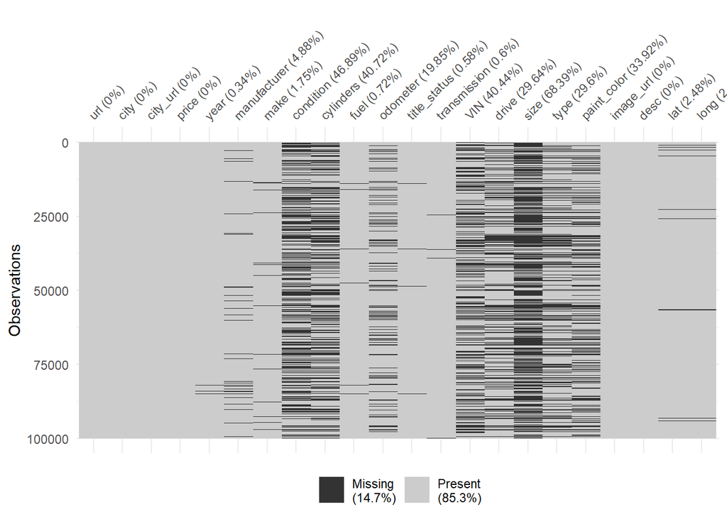

```r
#on plot les valeurs manquantes pour les 100 000 premières lignes
#un peu long
vis_miss(data[c(0:100000)], warn_large_data=F)
```

```r
#REMARQUE: il semble que certaines que le manque de données dans certaines variables
#ne soit pas aléatoire ==> on observe des patterns
navar= colSums(is.na(data))/nrow(data) # taux de na dans les colonnes (variable)
navar
```

```
##          url         city     city_url        price         year manufacturer
## 0.000000e+00 0.000000e+00 0.000000e+00 0.000000e+00 2.738481e-03 4.674244e-02
##         make    condition    cylinders         fuel     odometer title_status
## 1.642138e-02 4.677439e-01 4.001225e-01 8.167899e-03 1.874927e-01 5.372367e-03
## transmission          VIN        drive         size         type  paint_color
## 8.114651e-03 4.186072e-01 2.878524e-01 6.681132e-01 2.832293e-01 3.262082e-01
##    image_url         desc          lat         long
## 1.521378e-05 4.183790e-05 2.324095e-02 2.324095e-02
```

```r
naind= rowSums(is.na(data)) # taux na par individu
max(naind)
```

```
## [1] 18
```

```r
data= setDF(data)

col_names= colnames(Filter(is.character, data))
col_names
```

```
##  [1] "url"          "city"         "city_url"     "manufacturer" "make"
##  [6] "condition"    "cylinders"    "fuel"         "title_status" "transmission"
## [11] "VIN"          "drive"        "size"         "type"         "paint_color"
## [16] "image_url"    "desc"
```

```r
#un peu long !!
data[col_names] <- lapply(data[col_names] , factor)

str(data)
```

```
## 'data.frame':    525839 obs. of  22 variables:
##  $ url         : Factor w/ 525839 levels "https://abilene.craigslist.org/ctd/d/abilene-2008-chevy-3500hd-4wd-miles/7012193131.html",..: 174524 174382 171930 172006 171843 172671 172594 172600 172699 172775 ...
##  $ city        : Factor w/ 413 levels "abilene, TX",..: 132 132 132 132 132 132 132 132 132 132 ...
##  $ city_url    : Factor w/ 413 levels "https://abilene.craigslist.org",..: 134 134 134 134 134 134 134 134 134 134 ...
##  $ price       :integer64 1500 8900 7995 6995 20990 4950 6850 7995 ...
##  $ year        : int  2006 2009 2010 2007 2010 2010 2007 2007 2011 2013 ...
##  $ manufacturer: Factor w/ 41 levels "acura","alfa-romeo",..: 7 25 7 NA 35 38 15 24 18 39 ...
##  $ make        : Factor w/ 36971 levels "'09 Smart FORTWO convertible",..: 11478 23635 31647 19848 2659 21922 36829 13610 5806 26489 ...
##  $ condition   : Factor w/ 6 levels "excellent","fair",..: 3 NA NA NA 1 3 3 1 1 1 ...
##  $ cylinders   : Factor w/ 8 levels "10 cylinders",..: 6 NA NA NA 6 4 7 6 4 4 ...
##  $ fuel        : Factor w/ 5 levels "diesel","electric",..: 3 3 3 3 1 3 3 3 3 3 ...
##  $ odometer    : int  236000 119000 129105 164296 123213 253000 254000 146111 115048 72936 ...
##  $ title_status: Factor w/ 6 levels "clean","lien",..: 1 1 1 1 1 1 1 1 1 1 ...
##  $ transmission: Factor w/ 3 levels "automatic","manual",..: 1 1 1 1 1 1 1 1 1 1 ...
##  $ VIN         : Factor w/ 183529 levels "'Xxxxxxxx","-",..: NA NA 109355 125481 101328 117198 54332 NA NA NA ...
##  $ drive       : Factor w/ 3 levels "4wd","fwd","rwd": 3 NA NA NA 1 1 1 2 2 2 ...
##  $ size        : Factor w/ 4 levels "compact","full-size",..: 3 NA NA NA NA NA NA 1 1 1 ...
##  $ type        : Factor w/ 13 levels "bus","convertible",..: 3 NA NA NA NA 9 13 9 9 4 ...
##  $ paint_color : Factor w/ 12 levels "black","blue",..: 2 NA NA NA 11 11 1 11 2 11 ...
##  $ image_url   : Factor w/ 369183 levels "https://images.craigslist.org/00000_102AG964U25_600x450.jpg",..: 162859 56784 299017 67816 26783 338978 130962 269337 122481 332539 ...
##  $ desc        : Factor w/ 444073 levels "''SERVICE JUST DONE''\nDISTRIBUTOR CAP,\n,DISTIBUTOR ROTOR\n,SPARK PLUGS\n,PLUG WIRE SET\nTIMING BELT\n\n\n\n19"| __truncated__,..: 63403 371449 429544 429592 307214 111776 76780 78598 122228 334224 ...
##  $ lat         : num  42.6 43 43.2 43.2 42.8 ...
##  $ long        : num  -85.3 -85.7 -84.2 -84.2 -85.5 ...
```